# Suicide Rate Analysis

## Find features that affect suiside rate and predict U.S. teenager suicide rate in 2020

### Author: Yuting Zhong

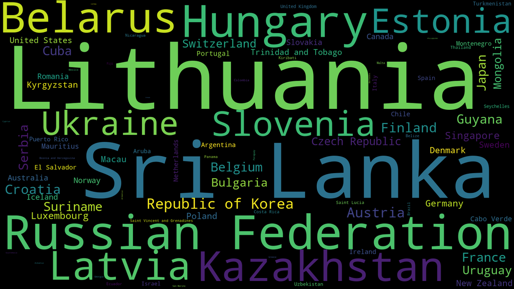

- Word could that represent suicide rate for each country

# Content:

### Step 1: View ource dataset

- Step 1a: Load Data
- Step 1b: View Data

### Step 2: Data cleaning

- Step 2a: Handling missing data
- Step 2b: Data Transformation

### Step 3: Data Visualization

- Step 3a: Average suiside rate for each country
- Step 3b: Use Word Cloud for visually presenting the maginitude of suicide rate in each country
- Step 3c: Average suiside rate on the world map
- Step 3d: Average suicide over time
  - Feature 1: Continent
  - Feature 2: Age
  - Feature 3: Gender
  - Feature 4: Generation
- Step 3E: Relationship between suicide rate and gdp per capita

### Step 4: Machine learning for prediction

- Step 4a: Preprocess data
- Step 4b: Train Model
- Step 4c: Test model accuracy
- Step 4d: Predict

### Step 5: Conclusion

*Please notice in this notebook we use `suisde rate` to represent number of suisides per 100,000 people in this notebook.

## Step 1: View source dataset

```python
import pandas as pd
import numpy as np
import matplotlib.pyplot as plt
import matplotlib
import seaborn as sns
```

```python
pd.options.display.max_columns = None
```

### Step 1a: Load Data

```python
data = pd.read_csv("master.csv") #Load data from a csv file to pandas dataframe
```

### Step 1b: View Data

- Make sure the data has been successfully loaded
- Familiar with the data
- Have some sense of which parts needs to be processed.

```python
data.head()
```

|  | country | year | sex | age | suicides_no | population | suicides/100k pop | country-year | HDI for year | gdp_for_year ($) | gdp_per_capita ($) | generation |
| --- | --- | --- | --- | --- | --- | --- | --- | --- | --- | --- | --- | --- |
| 0 | Albania | 1987 | male | 15-24 years | 21 | 312900 | 6.71 | Albania1987 | NaN | 2,156,624,900 | 796 | Generation X |
| 1 | Albania | 1987 | male | 35-54 years | 16 | 308000 | 5.19 | Albania1987 | NaN | 2,156,624,900 | 796 | Silent |
| 2 | Albania | 1987 | female | 15-24 years | 14 | 289700 | 4.83 | Albania1987 | NaN | 2,156,624,900 | 796 | Generation X |
| 3 | Albania | 1987 | male | 75+ years | 1 | 21800 | 4.59 | Albania1987 | NaN | 2,156,624,900 | 796 | G.I. Generation |
| 4 | Albania | 1987 | male | 25-34 years | 9 | 274300 | 3.28 | Albania1987 | NaN | 2,156,624,900 | 796 | Boomers |

## Step 2: Data Cleaning

- Modify the data, it will save your time on data analyzing, modeling.

### Step 2a: Handling missing data

- Missing data must be handled before doing any analysis. It could cause serious issue. For example, when you are calculating the mean of a group of large numbers, NaN might be 0 and the mean will be significantly affected.

```python
data.isnull().sum() #Calculate the sum of all NaN values appeared in each column
```

```
country                   0
year                      0
sex                       0
age                       0
suicides_no               0
population                0
suicides/100k pop         0
country-year              0
HDI for year          19456
 gdp_for_year ($)         0
gdp_per_capita ($)        0
generation                0
dtype: int64
```

```python
hdi_na_sum = data.isnull().sum()['HDI for year'] #Get the total number of NaNs in HDI for year column
size = len(data.index) #Get the total row number for the dataframe
missing_percentage = hdi_na_sum/size
print(missing_percentage)
```

```
0.699352983465133
```

69.9% of `HDI for year` is missing, so I decide to drop this column.

```python
data = data.drop(columns = ['HDI for year'],axis = 1) #Drop the column
```

```python
data.isnull().sum() #Check if there is any more missing data
```

```
country               0
year                  0
sex                   0
age                   0
suicides_no           0
population            0
suicides/100k pop     0
country-year          0
 gdp_for_year ($)     0
gdp_per_capita ($)    0
generation            0
dtype: int64
```

Zero missing data each column, we are safe to proceed now.

### Step 2b: Data Transformation

- Sometimes the catgorical data is represented by string. For example, in this dataset `sex` is marked as `male` and `female`. These cotegorical strings does not mean anything in math so we should convert them to numbers. And notice that the magnitude of these numbers could affect the result so we they have the same magnitude. Therefore, we need an identity matrix to hold all features and each vector in this identity matrix represents one unique feature. This method is called `one hot encoding`.

```python
data.sex.value_counts() #Display the sex distribution of this dataset
```

```
female    13910
male      13910
Name: sex, dtype: int64
```

```python
data.country.value_counts()
```

```
Netherlands               382
Austria                   382
Mauritius                 382
Iceland                   382
Luxembourg                372
                         ...
Bosnia and Herzegovina     24
Dominica                   12
Macau                      12
Cabo Verde                 12
Mongolia                   10
Name: country, Length: 101, dtype: int64
```

- From the result above, we can see that there are in total 101 countries. If I use one-hot encoding to split these countries, there will be too many categories(vectors) which will cause one hot encoding memory error. Therefore I find another way of processing these data which is group countries by continent.
- The python extension packagep `pycountry_convert` could help you convert country to continent. You will need to install the packege before importing.  
  `pip install pycountry-convert`.  
  [This is the link to pycountry_convert api](https://pypi.org/project/pycountry-convert/).
- Unfortunatelly, `pycontrv_convert` is no powerful enough to recognize the country name in this dataframe, so we will also need to install `country_converter` to convert all country names to ISO2 format, and then use the function from `pycontry_convert` to convert the ISO2 country code to continent.  
  `pip install country_converter --upgrade`  
  [This is the link to country converter api](https://pypi.org/project/country-converter/)

```python
import country_converter as coco

cc = coco.CountryConverter()
country_list = data.country.tolist() #Get the country names from dataframe and convert to list.
country_code = cc.convert(names = country_list, to = 'ISO2') # Convert country names to ISO2 country code

data['country_code'] = country_code #Add country code to dataframe
```

```python
import pycountry_convert as pc

data['continent'] = data.country_code.map(pc.country_alpha2_to_continent_code) #Convert country code to continent
data.head()
```

|  | country | year | sex | age | suicides_no | population | suicides/100k pop | country-year | gdp_for_year ($) | gdp_per_capita ($) | generation | country_code | continent |
| --- | --- | --- | --- | --- | --- | --- | --- | --- | --- | --- | --- | --- | --- |
| 0 | Albania | 1987 | male | 15-24 years | 21 | 312900 | 6.71 | Albania1987 | 2,156,624,900 | 796 | Generation X | AL | EU |
| 1 | Albania | 1987 | male | 35-54 years | 16 | 308000 | 5.19 | Albania1987 | 2,156,624,900 | 796 | Silent | AL | EU |
| 2 | Albania | 1987 | female | 15-24 years | 14 | 289700 | 4.83 | Albania1987 | 2,156,624,900 | 796 | Generation X | AL | EU |
| 3 | Albania | 1987 | male | 75+ years | 1 | 21800 | 4.59 | Albania1987 | 2,156,624,900 | 796 | G.I. Generation | AL | EU |
| 4 | Albania | 1987 | male | 25-34 years | 9 | 274300 | 3.28 | Albania1987 | 2,156,624,900 | 796 | Boomers | AL | EU |

```python
data.continent.value_counts() #Display the continent distribution of this dataset
```

```
EU    11418
NA     6058
AS     5366
SA     3156
OC      972
AF      850
Name: continent, dtype: int64
```

```python
data.age.value_counts()
```

```
15-24 years    4642
55-74 years    4642
25-34 years    4642
35-54 years    4642
75+ years      4642
5-14 years     4610
Name: age, dtype: int64
```

```python
data.generation.value_counts()
```

```
Generation X       6408
Silent             6364
Millenials         5844
Boomers            4990
G.I. Generation    2744
Generation Z       1470
Name: generation, dtype: int64
```

```python
data = data.drop(columns = [' gdp_for_year ($) ','population','suicides_no']) #Drop unnecessary columns
```

```python
data = data.rename(columns = {'suicides/100k pop':'suicide_rate', 'gdp_per_capita ($)':'gdp_per_capita'})#Rename columns
```

```python
data.head()
```

|  | country | year | sex | age | suicide_rate | country-year | gdp_per_capita | generation | country_code | continent |
| --- | --- | --- | --- | --- | --- | --- | --- | --- | --- | --- |
| 0 | Albania | 1987 | male | 15-24 years | 6.71 | Albania1987 | 796 | Generation X | AL | EU |
| 1 | Albania | 1987 | male | 35-54 years | 5.19 | Albania1987 | 796 | Silent | AL | EU |
| 2 | Albania | 1987 | female | 15-24 years | 4.83 | Albania1987 | 796 | Generation X | AL | EU |
| 3 | Albania | 1987 | male | 75+ years | 4.59 | Albania1987 | 796 | G.I. Generation | AL | EU |
| 4 | Albania | 1987 | male | 25-34 years | 3.28 | Albania1987 | 796 | Boomers | AL | EU |

## Step 3: Data Visualization

- It is easier for you to analyze data based on graph.

### Step 3a: Average suiside rate for each country

```python
country_suicide_df = data.groupby('country').mean() #Calculate the average suiside rate for each country across all years
country_suicide_df = country_suicide_df.sort_values('suicide_rate',  ascending=False) #Sort data by suiside rate
```

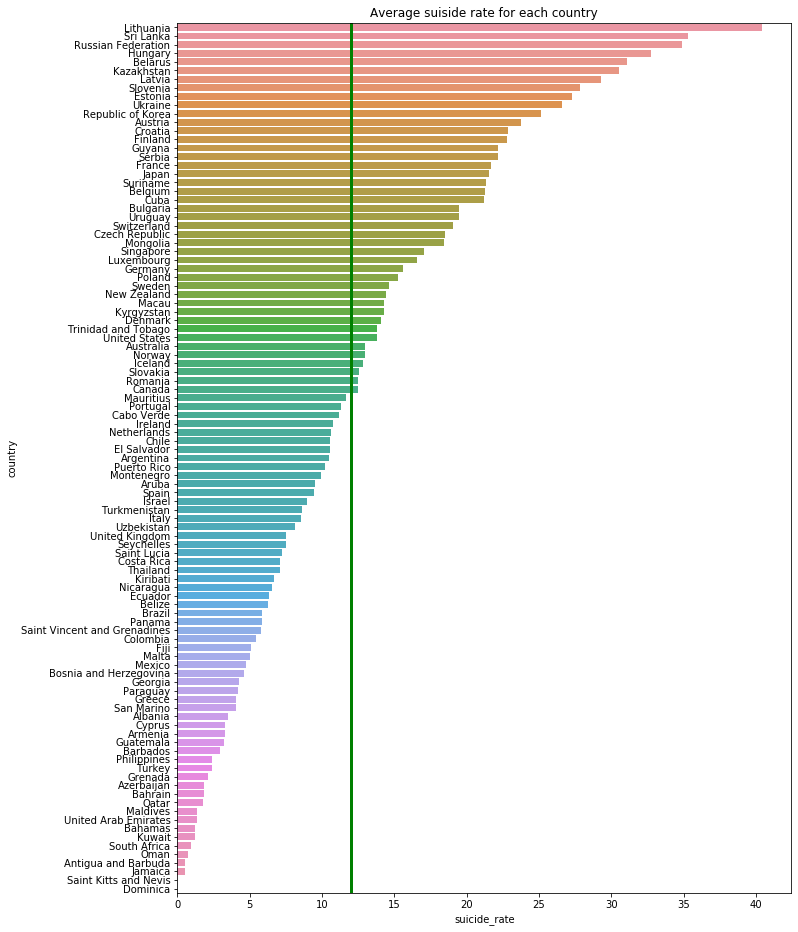

```python
matplotlib.rcParams['figure.figsize'] = [11, 16] #Change the size of the graph
fig, ax = plt.subplots()
plt.title("Average suiside rate for each country")
fig = sns.barplot(y=country_suicide_df.index, x=country_suicide_df['suicide_rate']) #Country names on y axis, suiside rate on x axis
ax.axvline(country_suicide_df['suicide_rate'].mean(), color="green", linewidth=3) #This green line indicates the world average suiside rate
```

### Step 3b: Use `Word Cloud` for visually presenting the maginitude of suicide rate in each country

- `Word Cloud` is a elegant way of visually presenting text data, in this case, country.

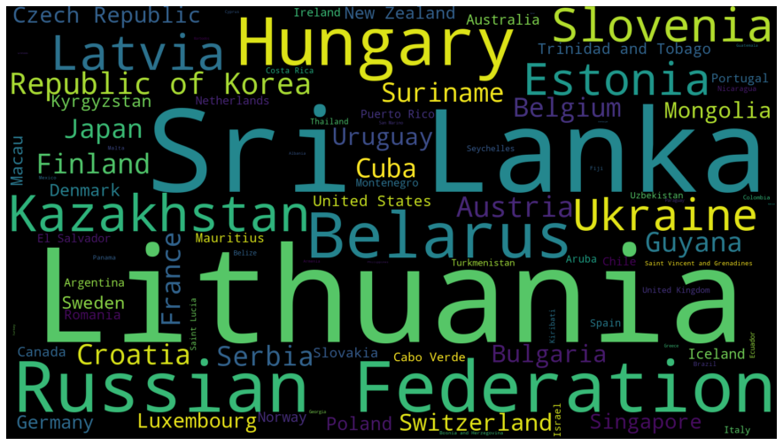

```python
matplotlib.rcParams['figure.figsize'] = [16, 9] # Change the size of the graph
wordcloud_df = country_suicide_df.iloc[:,1:2] # Create a new data frame that only contains country name and suicide rate
d = {} # Save the data to a dictionary
for k,v in wordcloud_df.iterrows():
    d[k] = v[0]

#Create a word cloud object
wc = WordCloud(width=1600,height=900, max_words=101,relative_scaling=1,normalize_plurals=False)
wc_img = wc.generate_from_frequencies(d)
wc_img.to_file('word_cloud.png')



plt.imshow(wc_img, interpolation='bilinear') # Display the image
plt.axis("off")
plt.show()
```

### Step 3c: Average suiside rate on the world map

- We will need this json file to indicate country coordinates. world-countries.json
- The `world-countries.json` converts `ISO3` country code to coordinates, so we will need to convert the country name to `ISO3` format.
- You can read more about `ISO3` by click this [link](https://unstats.un.org/unsd/tradekb/knowledgebase/country-code)

```python
import folium #We will use folium to visualize the data on the map
country_cord = 'world-countries.json'
```

```python
ISO3 = cc.convert(names = country_suiside_df.index.tolist(),to = 'ISO3') #Convert country name to ISO3 country code
country_suiside_df['ISO3'] = ISO3
```

```python
m = folium.Map() #Creat a new map

#We want to use the intensity of the green color to indicate the value of suiside rate in each country
m.choropleth(geo_data = country_cord, data = country_suiside_df,
             columns=['ISO3', 'suicide_rate'],
             key_on='feature.id',
             fill_color='YlGn', fill_opacity=0.7, line_opacity=0.2)
m
```

[interactive chart not shown]

- Notice that black area indicats there is no data in that country

### Step 3d: Average suicide over time

### General

- We want to see if there is a general trending for suicide rate over time.

```python
year_df = data.groupby('year').mean() #Calculate the average suiside rate for each year in the world
year_df.head()
```

| year | suicide_rate | gdp_per_capita |
| --- | --- | --- |
| 1985 | 11.826198 | 6091.229167 |
| 1986 | 11.423333 | 7126.104167 |
| 1987 | 11.644213 | 8712.592593 |
| 1988 | 12.709405 | 9983.857143 |
| 1989 | 12.879071 | 9725.038462 |

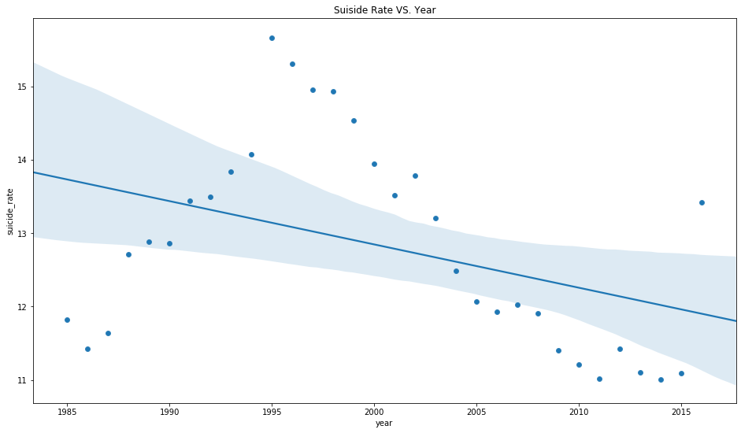

```python
year_df['year'] = year_df.index # Add back year feature to dataframe

x = year_df.year # x is year
y = year_df['suicide_rate'] #y is suicide rate

plt.title('Suiside Rate VS. Year')
ax = sns.scatterplot(x,y)
ax = sns.regplot(x = 'year', y = 'suicide_rate',data = year_df) #plot the linear regression line
```

- From the plot we can see that the suicide rate is increasing during 1985 to 1995 and 2015 to 2016, decreasing during 1995 to 2015. At the year 1995, the suicide rate reaches to the history maximun which mean there are nealy 16 out of 100,000 people killed themselves in 1995.
- The linear regression line indicates that in general the suicide rate is decreasing over time. However, this relationship is not obvious. Therefore, let's add some features to see if we could get some better relationships.

### Feature 1: Continent

- Previously we have seen that suicide rate varies among different countries. However, it is too much work to analyze suisde rate in each country. Therefore, instead of nationality, I would like to introduce a more general feature `continent` to see if this feature would give us some better linear regression lines that indicate the suicide rates over time.

```python
conti_df = data.groupby('continent').mean() # Calculate the average suicide rate for each continent
conti_df = conti_df.sort_values('suicide_rate', ascending=False) #Sort the data in descending order by suicide rate
```

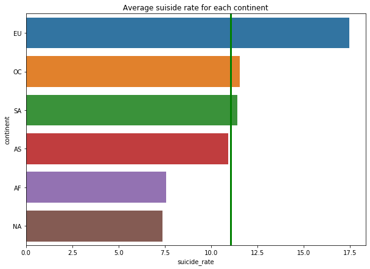

```python
matplotlib.rcParams['figure.figsize'] = [10, 7] #Change the size of the graph
fig, ax = plt.subplots()
plt.title("Average suicide rate for each continent")
fig = sns.barplot(y=conti_df.index, x=conti_df['suicide_rate']) #Continent names on y axis, suicide rate on x axis
ax.axvline(conti_df['suicide_rate'].mean(), color="green", linewidth=3) #This green line indicates the world average suiside rate
```

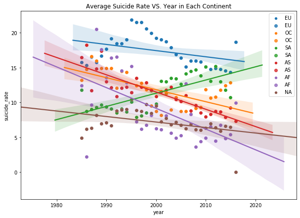

```python
for conti in conti_df.index:
    #Create a temp dataframe to store the data we want to plot
    curr_conti = data[data.continent == conti]
    curr_year = curr_conti.groupby('year').mean()
    curr_year['year'] = curr_year.index
    curr_year['conti'] = conti

    # year on x axis and suicide rate on y axis
    x = curr_year.index
    y = curr_year['suicide_rate']

    # Plot
    plt.title('Average Suicide Rate VS. Year in Each Continent')
    ax = sns.scatterplot(x,y,data = curr_year,label = conti)
    ax = sns.regplot(x = 'year', y = 'suicide_rate',data = curr_year, label = conti)
```

### Feature 2: Age

```python
age_suiside_df = data.groupby('age').mean() #Calculate the average suiside rate for age interval across all years
age_suiside_df = age_suiside_df.sort_values('suicide_rate',  ascending=False) #Sort data by suiside rate
```

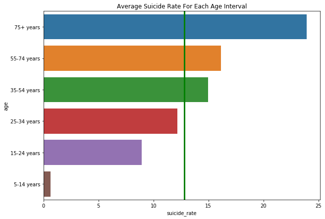

```python
fig, ax = plt.subplots()
plt.title("Average Suicide Rate For Each Age Interval")
fig = sns.barplot(y=age_suiside_df.index, x=age_suiside_df['suicide_rate']) #Country names on y axis, suiside rate on x axis
ax.axvline(age_suiside_df['suicide_rate'].mean(), color="green", linewidth=3) #This green line indicates the world average suiside rate
```

- This graph indicates the suiside rate increases as age getting older. In other words, Older people are more likely to kill themselves. Therefore, age is an important factor that affect the suicide rate. Let's see if this feature is giving us some better linear regression lines in suicide rate over time.

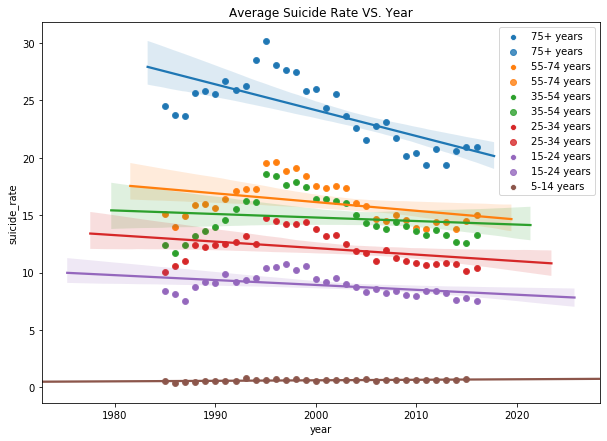

```python
for age in age_suiside_df.index:
    #Create a temp dataframe to store the data we want to plot
    curr_age = data[data.age == age]
    curr_year = curr_age.groupby('year').mean()
    curr_year['year'] = curr_year.index
    curr_year['age'] = age

    # year on x axis and suicide rate on y axis
    x = curr_year.index
    y = curr_year['suicide_rate']

    # Plot the graph
    plt.title('Average Suicide Rate VS. Year')
    ax = sns.scatterplot(x,y,data = curr_year,label = age)
    ax = sns.regplot(x = 'year', y = 'suicide_rate',data = curr_year, label = age)
```

- This graph clearly shows that in different age intervals, suiside rate over time is different.
- For people in age of 5-14, they tends to have a low and constant suicide rate over time. In other words, children keep the good habit of not commit suicides over time.
- Despite the fact that elders in age of 75+ has the hightest suicide rates among all age intervals, their suicide rate over time is decreasing than any other age intervals. Which means, there is an incresing amount of elders chose not to kill themselves as time goes by.

### Feature 3: Gender

```python
sex_suiside_df = data.groupby('sex').mean() #Calculate the average suiside rate for each gender across all years
sex_suiside_df = sex_suiside_df.sort_values('suicide_rate',  ascending=False) #Sort data by suiside rate
```

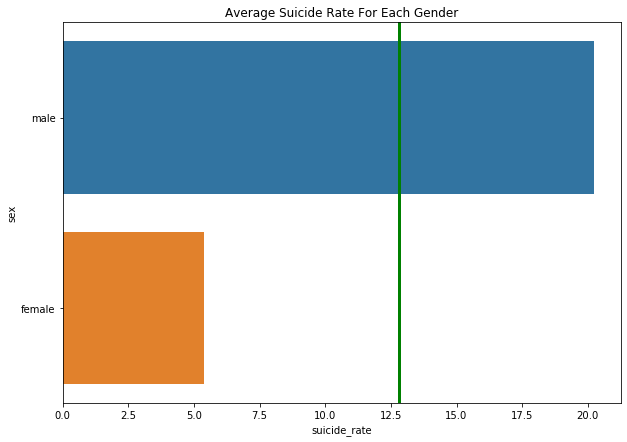

```python
fig, ax = plt.subplots()
plt.title("Average Suicide Rate For Each Gender")
fig = sns.barplot(y=sex_suiside_df.index, x=sex_suiside_df['suicide_rate']) #Genders on y axis, suiside rate on x axis
ax.axvline(sex_suiside_df['suicide_rate'].mean(), color="green", linewidth=3) #This green line indicates the world average suiside rate
```

- This bar plot indicates that the average suicide rate for male is significantly higher than the suicide rate for female. Therefore, gender is also an important feature that would affect the suiside rate. Let's add this feature to suicide rate over time.

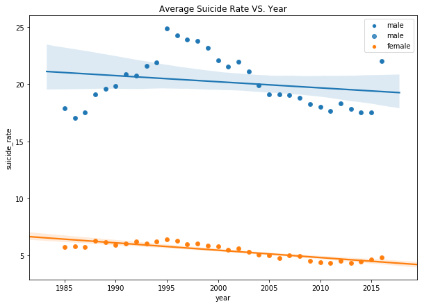

```python
for sex in sex_suiside_df.index:
    ##Create a temp dataframe to store the data we want to plot
    curr_sex = data[data.sex == sex]
    curr_year = curr_sex.groupby('year').mean()
    curr_year['year'] = curr_year.index
    curr_year['sex'] = sex

    # year on x axis and suicide rate on y axis
    x = curr_year.index
    y = curr_year['suicide_rate']

    # Plot
    plt.title('Average Suicide Rate VS. Year')
    ax = sns.scatterplot(x,y,data = curr_year,label = sex)
    ax = sns.regplot(x = 'year', y = 'suicide_rate',data = curr_year, label = sex)
```

- From the graph we can see that two linear regression lines have almost same slope but different y axis intercept, this indicats that overall suiside rate for male is greater than female rate and the suicide rates for both male and female are decreasing over time in a same rate.

### Feature 4: Generation

```python
generation_suiside_df = data.groupby('generation').mean() #Calculate the average suiside rate for each generation across all years
generation_suiside_df = generation_suiside_df.sort_values('suicide_rate',  ascending=False) #Sort data by suiside rate
```

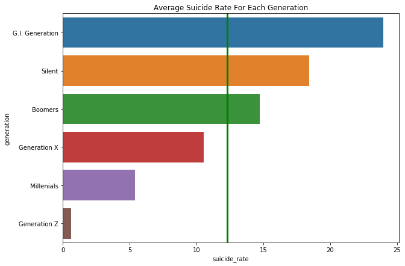

```python
fig, ax = plt.subplots()
plt.title("Average Suicide Rate For Each Generation")
fig = sns.barplot(y=generation_suiside_df.index, x=generation_suiside_df['suicide_rate']) #Generations on y axis, suicide rate on x axis
ax.axvline(generation_suiside_df['suicide_rate'].mean(), color="green", linewidth=3) #This green line indicates the world average suiside rate
```

- There are some suicide rate differences among different generation. The G.I. Generation has the highest average suicide rate and the Generation Z has the lowest suicide rate. Therefore the generation variable is a factor that affect the suicide rate. Let's add this feature to suicide rate over time to see if we could get any interesting result.

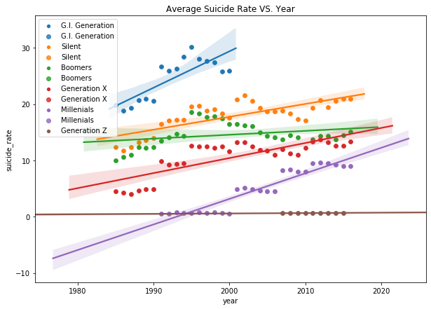

```python
for generation in generation_suiside_df.index:
    #Create a temp dataframe to store the data we want to plot
    curr_generation= data[data.generation == generation]
    curr_year = curr_generation.groupby('year').mean()
    curr_year['year'] = curr_year.index
    curr_year['generation'] = generation

    # year on x axis and suicide rate on y axis
    x = curr_year.index
    y = curr_year['suicide_rate']

    #Plot
    plt.title('Average Suicide Rate VS. Year')
    ax = sns.scatterplot(x,y,data = curr_year,label = generation)
    ax = sns.regplot(x = 'year', y = 'suicide_rate',data = curr_year, label = generation)
```

- Surprisingly, most generations have a increase suicide rate over time.

### Step 3E: Relationship between suicide rate and gdp per capita

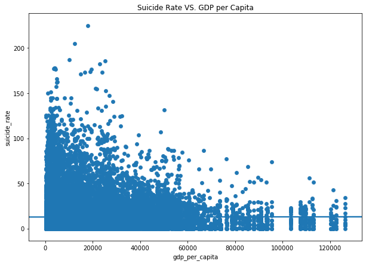

```python
x = data['gdp_per_capita'] #GDP per capita on x axis
y = data['suicide_rate'] #Suicide rate on y axis
plt.title('Suicide Rate VS. GDP per Capita')
ax = sns.scatterplot(x,y)
ax = sns.regplot(x,y)
```

- From the regression line, it is hard to tell the relationship between suicide rate and gdp per capita, but from the scatter, we can clearly tell that suicide rate decreases as gdp per capiita increases.

## Step 4: Machine learning for prediction

- Recalll: Our goal is to predict U.S. teenager suicide rate in 2020
- From part 3, we have seen that suicide rates for male and female are significantly different. Therefore,in order to build a more precise model, we have to add the gender feature to the model.

```python
from sklearn import model_selection
from sklearn import linear_model
```

### Step 4a: Preprocess data

- Data transformation on the categorical data
- Split the data to training and testing set

```python
ml_data = data.copy() # Create a machine learning data frame to apply some data transformation
ml_data = ml_data[ml_data.country_code == 'US'] # Only use the data that from U.S.
ml_data = ml_data[ml_data.age == '15-24 years'] # Only use the data collect from teenagers(15-24 years)

sex_dummy = pd.get_dummies(data.sex) # Apply one hot encodng on sex column to seperate sex to male and female indicators

ml_data = ml_data.join(sex_dummy) #Merge the sex indicators to our machine learning data frame

ml_data['male_w'] = ml_data['male'] * ml_data.year # Apply year as weight to male indicator
ml_data['female_w'] = ml_data['female'] * ml_data.year # Apply year as weight to female indicator

ml_data.head()
```

|  | country | year | sex | age | suicide_rate | country-year | gdp_per_capita | generation | country_code | continent | female | male | male_w | female_w |
| --- | --- | --- | --- | --- | --- | --- | --- | --- | --- | --- | --- | --- | --- | --- |
| 26852 | United States | 1985 | male | 15-24 years | 21.38 | United States1985 | 19693 | Generation X | US | NA | 0 | 1 | 1985 | 0 |
| 26857 | United States | 1985 | female | 15-24 years | 4.36 | United States1985 | 19693 | Generation X | US | NA | 1 | 0 | 0 | 1985 |
| 26864 | United States | 1986 | male | 15-24 years | 21.69 | United States1986 | 20588 | Generation X | US | NA | 0 | 1 | 1986 | 0 |
| 26869 | United States | 1986 | female | 15-24 years | 4.37 | United States1986 | 20588 | Generation X | US | NA | 1 | 0 | 0 | 1986 |
| 26876 | United States | 1987 | male | 15-24 years | 21.26 | United States1987 | 21631 | Generation X | US | NA | 0 | 1 | 1987 | 0 |

```python
# Cast the data to numpy array
X = np.array(ml_data[['male_w','female_w']]) # Selet weighted sex indicator as the input of our model
y= np.array(ml_data.suicide_rate)# Selet the suicide rate as the result of our model.

#Split the data to training and testing set
X_train, X_test, y_train, y_test = model_selection.train_test_split(X, y, test_size=0.2)
```

### Step 4b: Train Model

```python
regr = linear_model.LinearRegression()
regr.fit(X_train,y_train)
```

```
LinearRegression(copy_X=True, fit_intercept=True, n_jobs=None, normalize=False)
```

### Step 4c: Test model accuracy

- Use X_test and y_test to calculate the score of our model

```python
regr.score(X_test,y_test)
```

```
0.9475043748245316
```

- The score for our multiple linear regression model is 0.95, this is a pretty good score, we could rely on this model to make our prediction.

### Step 4d: Predict

```python
[male_res] = regr.predict([[2020,0]]) # Predict sucide rate for male in 2020
[female_res] = regr.predict([[0,2020]])# Predict suicide rate for female in 202
print('The suicide rate for U.S. male teenager in 2020 will be ' + str(male_res) + ' per 100k population')
print('The suicide rate for U.S. male teenager in 2020 will be ' + str(female_res) + ' per 100k population')
```

```
The suicide rate for U.S. male teenager in 2020 will be 16.79581188470192 per 100k population
The suicide rate for U.S. male teenager in 2020 will be 1.2730288642546554 per 100k population
```

## Step 5: Conclusion

In this notebook, I have produced a lot of graphs. It is not hard to see that data visualization is a good and intuitive way to extract hidden information from data. In part 3a(analyze the average suicide rate for each country), I ranked the suicide rate for different country by using a horizontal bar plot; In part 3b(Use Word Cloud for visually presenting the maginitude of suicide rate in each country)I use word clound to make the ranking result even more elegant; In part 3c( Average suiside rate on the world map) I created a choropleth map to show the suicide rate on the world map, the deeper color is, the higher suicide rate will be on that aera. The inofrmation conveyed by these graphs is so clear that could be understood by any one in any country. In part 3d(Average suicide over time), I used a scatter plot and discovered that there is a downward sloping linear relationship between suicide rate and time but this relationship is too general, so we went further to see what are the features that affect the suicide rate and would we get a more clear relationship on suicide rate over time based on those features. Luckily we have found some features that highly related to the suicide rate: continent, age, gender and generation. Then, I applied these features to the suicide rate over time and find some better fit linear regression lines. Most of these linear relationships are downward sloping linear relationships, which mean under these features there is a dercreasing suicide rate over time. However we also find some upward sloping linear relationship. For example, in SA(South and Central America) the suicide rate is increasing over time. This is a important hidden feature I have discovered and this is the reason why we want to analyze data in depth.

The goal of writing this notebook is to predict the U.S. teenager suicide rate in 2020. From the data visualization part, we have discoverd the folllowing facts: 1.There is a decrasing suicide rate over time in general. 2.The suicide rate over time is varied from different country, different geneder and different age. Therefore, to build a precise model, we have to consider some of these features. Instead of using all the data, I chose to extract the data that from U.S. and the age range is on 15-24 years. I am doing this because I want my model tragets on U.S. teenagers so we do not have to add country and age features on the model later on. However, use the targetting data is still not enough to train a good model. Recall from part3d, male suicide rate is much higher than female suicide rate, therefore, we have to add gender feature to our model. I use on-hot encoding method to split the gender feature to gender indicators. It is better for feeding the model and there is no bias between two genders. Finally, I trained my model and got a score of 0.95 which is pretty accurate, I can rely on this model to make our prediction.